# Anatomically Constrained Neural Networks (ACNN): Application to Cardiac Image Enhancement and Segmentation

2018-09-26

## 1. どんなもの？

- CNNに解剖学的事前知識を組み込む一般的な学習戦略を提案
- 学習された形状の非線形表現を通して，基礎となる大局的な解剖特性に従うようにモデルを持っていく
- 超解像と心臓のセグメンテーションを行っている
  - 心臓をセグメンテーションする際には，解像度を上げながらセグメンテーションをしている点がすごい

## 2. 先行研究と比べてどこがすごいの？

- 学習された3D形状深層モデルが，心臓病理学のクラス分類のためのバイオマーカーとして解釈の仕方と利用できることを実証する．
- 医用画像分析タスクのためのNNsに，形状とラベル構造上の事前知識を組み込む最新の技術を提案

## 3. 技術や手法の“キモ”はどこにある？

- 新しい正則化ネットワークを提案
- computer graphicsで使われるT-L構造に基づいている．
- 解剖の非線形コンパクト表現を得るために，autoencoderとT-Lネットワークモデルを利用

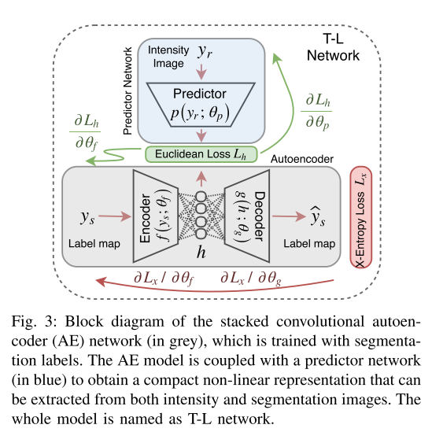

  Figure 1

- 全体のネットワークでT-Lネットみたいね
- T-Lモデルは2つのステージで訓練
  - AEをGT maskをcross-entropyを使って訓練
  - predictorが学習された空間hと一致するように，ユークリッド距離を使って訓練
  - これが終わったら，AEのencoder fの部分をcross entropyとeuclideanを使って更新
- 全体の構成

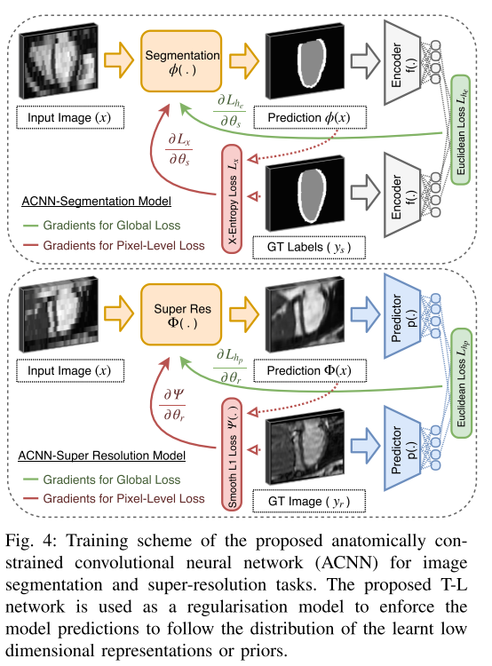

- φの関数

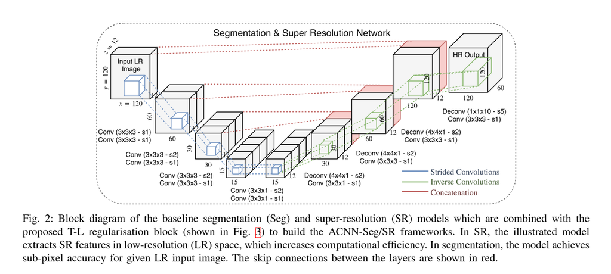

- SRの目的関数

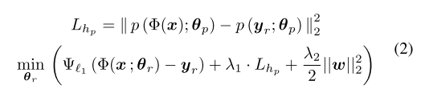

  - weight decay, pixel-wise loss, global loss
  - λ1，λ2は事前形状の重みとweight decay項の重みを決定する
  - global loss LhpはGT HRと合成されたHRから生成されたコードかんのユークリッド距離
- もしsmooth l1 lossだけを使うなら
- 結局，必要なデータ
  - 心臓セグメンテーションマスク（AEを訓練するために）
  - intensity画像

## 4. どうやって有効だと検証した？

- Full paper辛いので，SRの部分だけ
- データセット
  - UK Digital Heart Project Dataset
  - CETUS’14 Challenge Dataset
  - ACDC MICCAI’17 Challenge Dataset
- 超解像での評価値は，SSIMとMOSテスト
- 訓練1000，テスト200
- LR-HRのClinicalデータ両方を用いて，評価した
- 訓練中は，LR画像はMR acquisition modelを使って，clinical HRデータから人工的に生成された

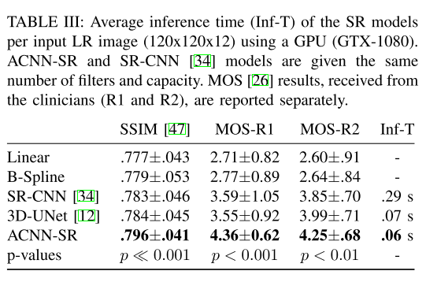

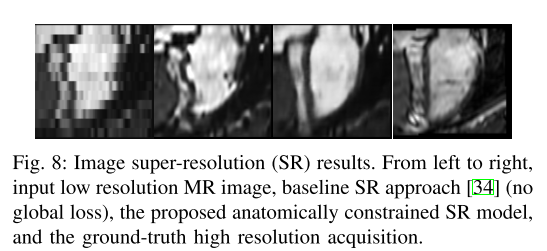

## 5. 議論はあるか？

- 心臓のHRとLRが揃っているのに，超解像を行っていない．
- 人工的に，多分ダウンサンプリングしている気がする
  - 読み違い？？
- 画像サイズが小さいからこういうのができるんでね

## 6. 次に読むべき論文はあるか？

- MR acquisition model
  - H. Greenspan. Super-resolution in medical imaging. The Computer Journal, 52(1):43–63, 2009.
- 心臓のSRのSOTA
  - O. Oktay, W. Bai, M. Lee, R. Guerrero, K. Kamnitsas, J. Caballero, A. de Marvao, S. Cook, D. ORegan, and D. Rueckert. Multi-input cardiac image super-resolution using convolutional neural networks. In International Conference on MICCAI, pages 246–254. Springer, 2016.
- T-L architecture
  - R. Girdhar, D. F. Fouhey, M. Rodriguez, and A. Gupta. Learning a predictable and generative vector representation for objects. In ECCV, pages 484–499. Springer, 2016.
- 基礎となるネットワーク構造
  - A. Sharma, O. Grau, and M. Fritz. Vconv-dae: Deep volumetric shape learning without object labels. In ECCV Workshops, pages 236–250. Springer, 2016.

### 論文情報・リンク

- [Oktay, O., Ferrante, E., Kamnitsas, K., Heinrich, M., Bai, W., Caballero, J., … Rueckert, D. (2017). Anatomically Constrained Neural Networks (ACNN): Application to Cardiac Image Enhancement and Segmentation, 1–13. https://doi.org/10.1109/TMI.2017.2743464](https://arxiv.org/pdf/1705.08302.pdf)